# A3: Analyzing SPL Library Checkouts for Popular Romance Novels

### Introduction

The data used in this report came from the Seattle Public Library. It includes the history of items that were checked out at least 10 times from 2017 through 2023. This report will analyze the checkout trends from 4 romance novels that were published during the 21st century including:

- The Time Traveler’s Wife (2003) by Audrey Niffenegger
- Call me by Your Name (2007) by André Aciman
- The Fault in Our Stars (2012) by John Green
- Everything, Everything (2015) by Nicola Yoon

More specifically, since all books analyzed were published before the COVID 19 pandemic this report will seek to understand any differences in the checkout history due to the pandemic as well as understanding what are the most common platforms readers are using (books, ebooks, & audio books). I am interested in these books in particular since I have read them all during the pandemic, I think it would be interesting to compare their popularity.

### Summary Information

During 2017 to 2023 there was a total of **9355** checkouts across all four romance novels. The most popular author was **André Aciman**, his book, *Call me by Your Name*, had over **4848** checkouts. On the other hand, the least popular author was **John Green**. His book, *The Fault in Our Stars*, only had a total of **1004** checkouts. The year with greatest number of checkouts for all four novels was **2018**, and the year with the least number of checkouts was **2023**.

### The Dataset

The data was collected by the Seattle Public Library, and can be found on [Seattle Open Data](https://data.seattle.gov/Community/Checkouts-by-Title/tmmm-ytt6). It was generated using a monthly count of checkouts per physical and digital items since April 2005 to February 2023 at the Seattle Public Library. A majority of SPL’s books are offered through digital platforms such as ebooks and audio books. They also offer video disks, movies, and even magazines. The data set has a wide range of genres including biographies, nonfiction, fantasy, romance, mystery, and more. They also have items that are produced in non-English languages.

The data set I am using is a filtered version using items that were checked out at least 10 times during 2017-2023. It denotes whether an item is physical or digital, the checkout method, material type, date, title, author, publisher, and genres. Certain limitations to consider while working with this data is that there often different versions of the item created, which can make it difficult to find all versions of an item. In addition, some author’s names and item title’s exist in different formats. Since the ISBN for many items are not provided, thus it is difficult to differentiate all forms of the item. In addition, the dataset does not include all data for 2023, thus while analyzing data in 2023, low checkout values are expected from the short time frame.

### First Trends Over Time: Novel Checkouts per Year

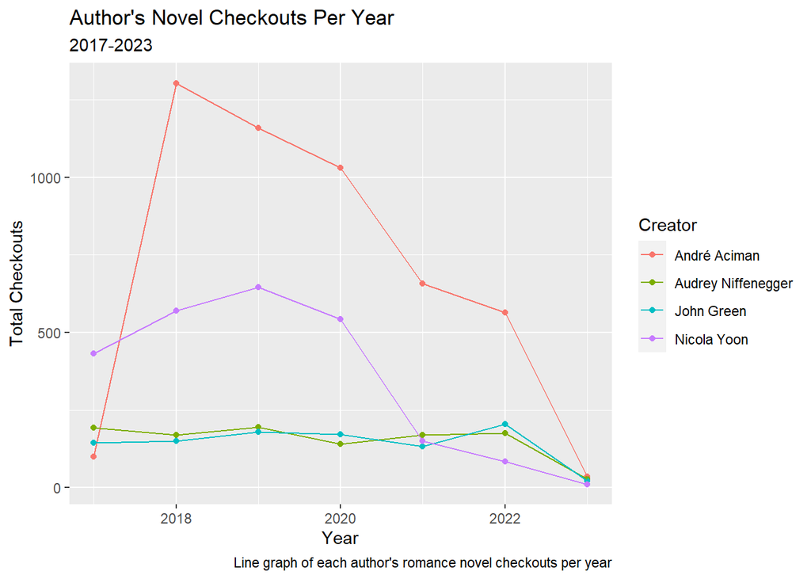

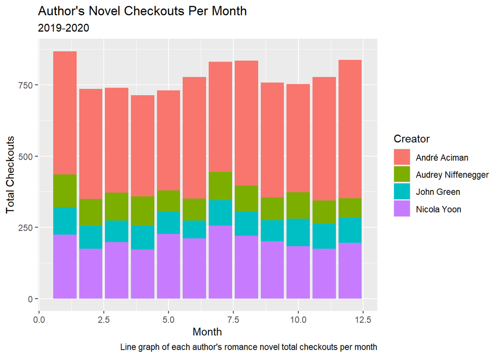

### Audio vs Ebook preferences

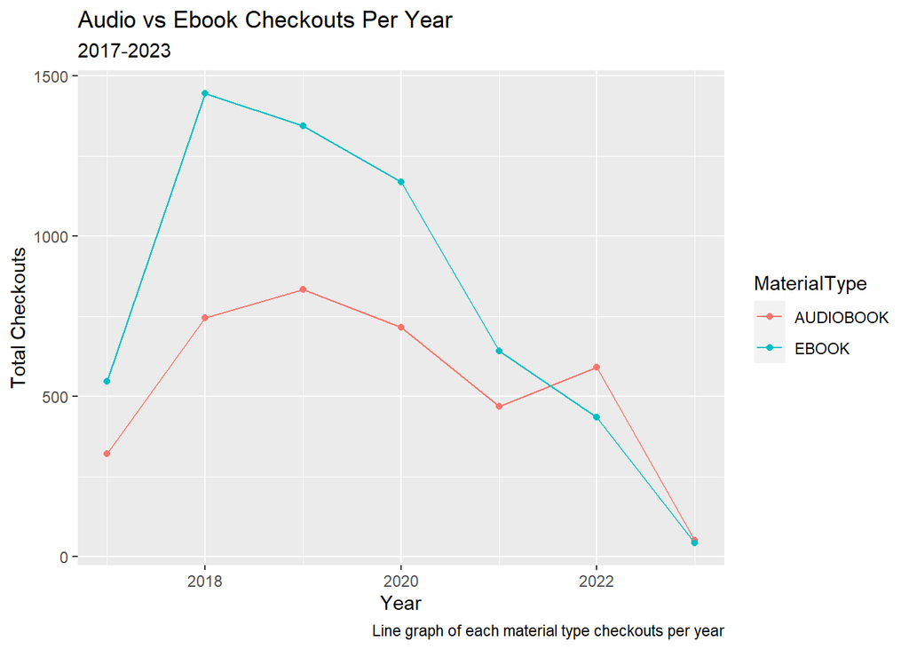

The chart depicts the total checkout history for Audio vs. Ebook over time using data from the four romance novels. Overall Ebook was the most preferred platform for users, but after late 2021, audio books became increasingly more popular.